# Introduction to Social Networks Analysis

### J. Adrián Sánchez

[schzcas.com](http://www.schzcas.com/)  
[@schzcas](https://twitter.com/schzcas)  
[github.com/shczcas](https://github.com/schzcas)

# Networks

##### Networks, An Introduction, M.E.J. Newman, Oxford University Press, 2010

### Why Networks?

There are many **systems** of interest to scientist that are composed of individual parts or components **linked** together in some way.

One of the most important aspects of systems is the **interactive behavior** of the system (sometimes neglected), which is the pattern of connections between components.

The idea is that the pattern of connectiosn in a given system can be represented as a **network**.

### So, what is a network?

In its simple form, a collection of points joined together in pairs by lines.

- Points are referred to as **vertices** or **nodes**
- Lines are referred to as **edges**.

### Visualization

A first step in **analyzing** the **structure** of a network is often to make a picture of it.  
**Visualization** can be an extraordinary useful tool in the analysis of network data.

### The Visualization Problem

Direct visualization of networks is only really usefull for networks up to a hundred or thousands vertices.  
Many of the networks that scientist are interested us today have thousands or even millions of vertices, which means that that visualziation is not of much help.

### Understanding the network structure

Unless we know something about the **structure** of these networks, we can not hope to understand fully how the corresponding **systems work**.

### Properties of Networks

In response to this need, network theory (or **graph theory**) has developed a large toolset of **measures and metrics** that can help us understand what our network data are telling us, even in cases where visualziation is impossible.  
At the core our aim is to answer the following questions:

- What is the **form and function** of the system the network represents?
- What **properties** of networked systems can we **measure?** With which particular **method**?
- How are those **properties related** to the practial issue we care about?

### Structural Analysis

The inquiry for **understanding** the **network** by its **properties and measures** is called **Structural Analysis**.

Primarilly is concerned with:

- Centrality (nodes or edges)
- Hubs (vertices with unusually high degree)
- Community detection or clustering

# Basic Methods for Analyzing Networks

##### Social Networks Analysis , David Knoke and Song Yang, Sage Publications, 2008.

### Graphs

Points and lines, also define a graph, thus allowing applications of concepts and **theorems from graph theory**.

A network or graph is a set of nodes and edges.  
Represented by **nodes** or **vertices**.  
Relations or ties are represented by **edges**.

```python
import networkx as nx
import matplotlib.pyplot as plt
plt.style.use('ggplot')
%matplotlib inline
```

```python
G=nx.Graph() #G is an empty Graph
```

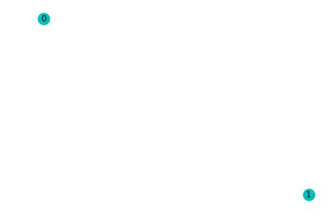

```python
Nodes=range(2)
G.add_nodes_from(Nodes)
nx.draw(G, node_color='c',edge_color='k', with_labels=True)
```

### Adjacent

Two nodes are **adjacent** if a line exists between them.

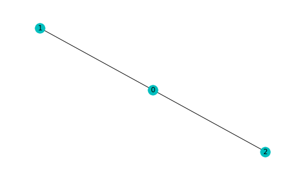

```python
G.add_edge(0,1)
G.add_edge(0,2)

nx.draw(G, node_color='c',edge_color='k', with_labels=True)
```

### Directed network or digraph

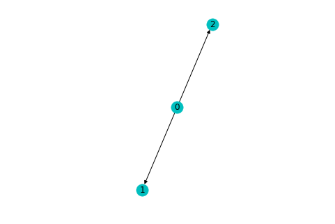

```python
D = nx.DiGraph()

Nodes=range(2)
D.add_nodes_from(Nodes)

D.add_edge(0,1)
D.add_edge(0,2)

nx.draw(D, node_color='c',edge_color='k', with_labels=True)
```

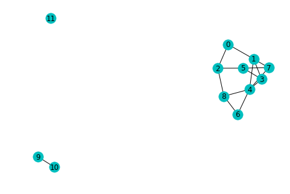

```python
Nodes=range(3,12)
G.add_nodes_from(Nodes)

Edges=[(1,3), (1,4), (1,7), (2,5), (2,8), (3, 4), (3,5),(4,6), (4,7), (4,8), (5,7),(6,8),(9,10)]
G.add_edges_from(Edges)

nx.draw(G, node_color='c',edge_color='k', with_labels=True)
```

### Subgraph

Is a **subset** of the nodes and edges in a graph.

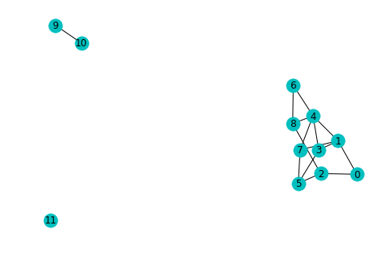

```python
nx.draw(G, node_color='c',edge_color='k', with_labels=True)
```

### Singletons, dyad triad

Nodes that have no edges are called **singletons**.  
Graphs composed of two nodes and a relationship are called **dyad**.  
Graphs composed of three nodes and a relationship are called **triad**

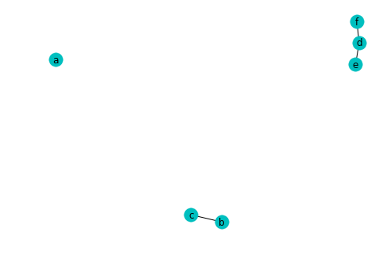

```python
u = nx.Graph()
Nodes=[("a"),("b"), ("c"), ("d"), ("e"), ("f")]
u.add_nodes_from(Nodes)

Edges=[("b","c"), ("d","e"), ("d","f") ]
u.add_edges_from(Edges)



nx.draw(u, node_color='c',edge_color='k', with_labels=True)
```

### Clique

When every node is conected to every other nodes is called a clique

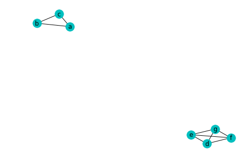

```python
q = nx.Graph()
Nodes=[("a"), ("b"), ("c"), ("d"), ("e"), ("f"), ("g")]
q.add_nodes_from(Nodes)

Edges=[("a","b"), ("a","c"),("b","c"), ("d","e"), ("d","f"), ("d","g"), ("e","f"), ("f","g"), ("g","e") ]
q.add_edges_from(Edges)

nx.draw(q, node_color='c',edge_color='k', with_labels=True)
```

### Clusters

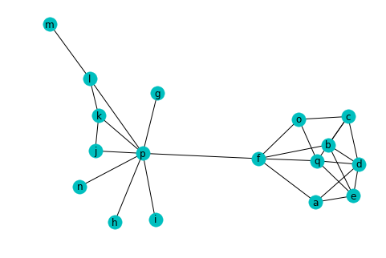

```python
c = nx.Graph()
Nodes=[("a"), ("b"), ("c"), ("d"), ("e"), ("f"), ("g"), ("h"), ("i"), ("j"), ("k"), ("l"), ("m"), ("n"), ("o"), ("p")]
c.add_nodes_from(Nodes)

Edges=[("a","e"), ("a","f"),("a","d"), ("d","q"), ("d","e"), ("d","b"), ("d","c"), ("e","q"), ("e","b"), ("q","f"), ("q","o",), ("q","c"), ("f","o"), ("f","b"), ("c","b"), ("c","o") , ("f","p"), ("p","g"), ("p","j"), ("p","i"), ("p","h"), ("j","k"), ("k","l"), ("k","p"), ("l","m"), ("l","p"), ("n","p"), ("l","m"), ("n","p")]
c.add_edges_from(Edges)

nx.draw(c, node_color='c',edge_color='k', with_labels=True)
```

### Egocentric Network

When a network is pulled by selecting a node and all of its connections is considered a egocentric network  
**degree-1 egocentric network**

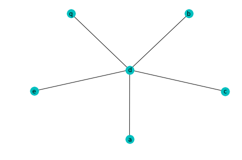

```python
e = nx.Graph()
Nodes=[("d"), ("q"), ("e"), ("b"),("c"), ("a")]
e.add_nodes_from(Nodes)

Edges=[("d","q"), ("d","e"), ("d","b"), ("d","c"), ("d","a") ]
e.add_edges_from(Edges)

nx.draw(e, node_color='c',edge_color='k', with_labels=True)
```

### Egocentric Network

When a network is pulled by selecting a node and all of its connections is considered a egocentric network  
**degree-1.5 egocentric network**

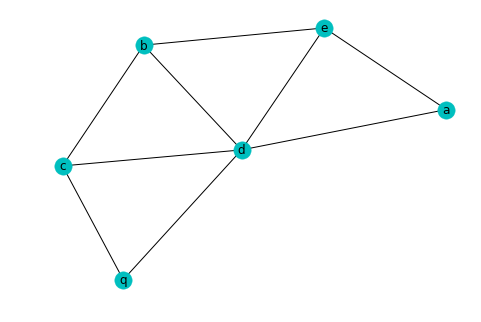

```python
e2 = nx.Graph()
Nodes=[("d"), ("q"), ("e"), ("b"),("c"), ("a")]
e2.add_nodes_from(Nodes)

Edges=[("d","q"), ("d","e"), ("d","b"), ("d","c"), ("d","a"), ("a","e"), ("e","b"), ("b","c"), ("c","q"), ]
e2.add_edges_from(Edges)

nx.draw(e2, node_color='c',edge_color='k', with_labels=True)
```

### Degree (Non-directed)

The Degree is the number of edges that separatees a node from another

```python
nx.degree(e)
```

```
DegreeView({'d': 5, 'q': 1, 'e': 1, 'b': 1, 'c': 1, 'a': 1})
```

#### In-degree (directed)

The in degree is the number of edges that are entering a node from another.

```
The in degree of node 0 is 0
The in degree of node 1 is 1
```

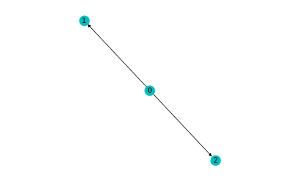

```python
nx.draw(D, node_color='c',edge_color='k', with_labels=True)
print ("The in degree of node 0 is", D.in_degree(0))
print ("The in degree of node 1 is", D.in_degree(1))
```

### Out-degree (directed)

The out degree is the number of edges that are going out from a node to another.

```
The in degree of node 0 is 2
The in degree of node 1 is 0
```

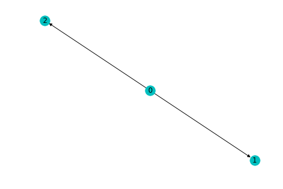

```python
nx.draw(D, node_color='c',edge_color='k', with_labels=True)
print ("The in degree of node 0 is", D.out_degree(0))
print ("The in degree of node 1 is", D.out_degree(1))
```

### Path

A Path is a **series of nodes** that can be traversed **following edges** between them.  
The length of the path is the number of edges in it.  
Paths are used to determine **connectedness**  
Two nodes in a graph are called **connected** if there is a path between them in the network.

We are interested in the **shortest path**, that is called the **geodesic distance** between node 0 and 6 for example.

```
The path from node 0 to node 6 is [0, 1, 4, 6]
```

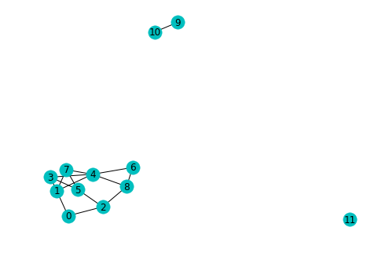

```python
print("The path from node 0 to node 6 is", nx.shortest_path(G,source=0,target=6))

nx.draw(G, node_color='c',edge_color='k', with_labels=True)
```

### Bridge and hubs

A **bridge** is an edge that connects two otherwise separate group of nodes in the networks. A node is a **cutpoint** if its removal will disconect the graph. **Hubs** are refer to the most connected nodes in the network.

```
The edge between node p and f is a bridge
Node p  is a hub
```

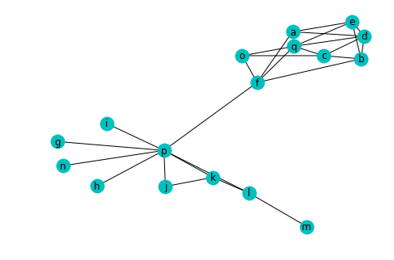

```python
print("The edge between node p and f is a bridge")

print("Node p  is a hub")

nx.draw(c, node_color='c',edge_color='k', with_labels=True)
```

# Network Structure and Measures

##### Analizing the Socil Web, Jennifer Goldbeck, Elsevier, 2013.

### Centrality

Centrality measures how central a node is in the network

### Degree Centrality

#### Undirected- unweighted graphs

Number of edges it has.  
Is a good measure of the total connection a node has, but will not necessarily indicate the importance of a node in connecting others or how central it is to the main group.

The degree centrality values are normalized by dividing by the maximum possible degree in a simple graph n-1 where n is the number of nodes in G.
$$\frac{degree_i}{n-1}$$

```
The node a degree is 3 and its degree centrality is 0.1875
The node b degree is 4 and its degree centrality is 0.25
The node g degree is 1 and its degree centrality is 0.0625
The node j degree is 2 and its degree centrality is 0.125
The node p degree is 8 and its degree centrality is 0.5
```

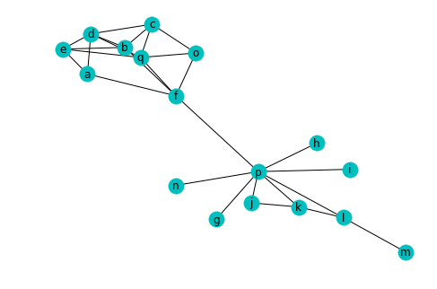

```python
nodes=[("a"), ("b"),("g"), ("j"), ("p")]
for i in nodes:
    print("The node", i, "degree is", nx.degree(c)[i], "and its degree centrality is", nx.degree_centrality(c)[i])

nx.draw(c, node_color='c',edge_color='k', with_labels=True)
```

### Closeness centrality

How close a node is to all other nodes.  
It is calculated as the average of the shortest path length from the node to every other node in the network.  
Indicates nodes as **more central** if they are closer to the most nodes in the graph, i.e., visual centrality.  
You can also see **Closness centrality** as the cost of spread (info) to al other nodes.

Closeness centrality of a node *u* is the reciprocal of the sum of the shortest path distances from *u* to all *n-1* other nodes.  
Since the sum of distances depends on the number of nodes in the graph, closeness is normalized by the sum of minimum possible distances n-1.

$$C(u) = \frac{n - 1}{\sum_{v=1}^{n-1} d(v, u)}$$

where *d(v, u)* is the shortest-path distance between *v* and *u*, and *n* is the number of nodes in the graph.

```python
nx.closeness_centrality(c, u=None, distance=None)
```

```
{'a': 0.42105263157894735,
 'b': 0.43243243243243246,
 'c': 0.34782608695652173,
 'd': 0.35555555555555557,
 'e': 0.34782608695652173,
 'f': 0.5714285714285714,
 'g': 0.38095238095238093,
 'h': 0.38095238095238093,
 'i': 0.38095238095238093,
 'j': 0.3902439024390244,
 'k': 0.41025641025641024,
 'l': 0.41025641025641024,
 'm': 0.2962962962962963,
 'n': 0.38095238095238093,
 'o': 0.42105263157894735,
 'p': 0.5925925925925926,
 'q': 0.4444444444444444}
```

### Betweenes centrality

How important a node is to the shortest paths through the network.  
We select a pair of nodes and find all the shortest paths between those nodes . Then we compute the fraction of those shortest paths that include node N.

It captures how important a node is in the flow of information from one part of the network to another

Betweenness centrality of a node v is the sum of the fraction of all-pairs shortest paths that pass through v:

$$c_B(v) =\sum_{s,t \in V} \frac{\sigma(s, t|v)}{\sigma(s, t)}$$

where $V$ is the set of nodes, $\sigma(s, t)$ is the number of shortest $(s, t)$-paths, and $\sigma(s, t|v)$ is the number of those paths passing through some node $v$ other than $s, t$. If $s = t$, $\sigma(s, t) = 1$, and if $v$ $\in {s, t}$, $\sigma(s, t|v) = 0$.

```python
nx.betweenness_centrality(c, normalized = True)
```

```
{'a': 0.05555555555555553,
 'b': 0.08611111111111111,
 'c': 0.010416666666666666,
 'd': 0.01875,
 'e': 0.007638888888888889,
 'f': 0.545138888888889,
 'g': 0.0,
 'h': 0.0,
 'i': 0.0,
 'j': 0.0,
 'k': 0.008333333333333333,
 'l': 0.125,
 'm': 0.0,
 'n': 0.0,
 'o': 0.027777777777777766,
 'p': 0.725,
 'q': 0.09861111111111112}
```

### Eigenvector centrality

Measures a node's importance while giving consideration to the importance of its neighbors. To determinice a node's influence in the network, it performs a matrix calculation to determine what is called the principal eigenvector using the adjacency matrix.

Eigenvector centrality computes the centrality for a node based on the centrality of its neighbors. The eigenvector centrality for node $i$ is

$\mathbf{Ax} = \lambda \mathbf{x}$

where $A$ is the adjacency matrix of the graph $G$ with eigenvalue $\lambda$. By virtue of the Perron–Frobenius theorem, there is a unique and positive solution if &\lambda& is the largest eigenvalue associated with the eigenvector of the adjacency matrix $A$.

```python
nx.eigenvector_centrality(c)
```

```
{'a': 0.26452916905550367,
 'b': 0.34700553982784327,
 'c': 0.3437034301110334,
 'd': 0.4102001192305686,
 'e': 0.3436849671854802,
 'f': 0.34848489621894313,
 'g': 0.03973714349253509,
 'h': 0.03973714349253509,
 'i': 0.03973714349253509,
 'j': 0.05590901404320553,
 'k': 0.06739030377434223,
 'l': 0.05932543579772602,
 'm': 0.014236515860812851,
 'n': 0.03973714349253509,
 'o': 0.2646059988654564,
 'p': 0.1655922503548747,
 'q': 0.41050147610359156}
```

For example, a node with 300 relatively unpopular friends on Facebook would have lower eigenvector centrality than someone with 300 very popular friends, like Barack Obama.

A variant of eigenvector centrality is at the core of Google's PageRank algorithm.

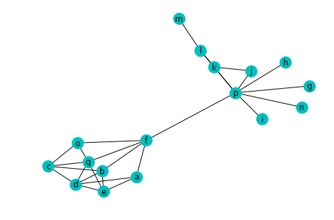

```python
nx.draw(c, node_color='c',edge_color='k', with_labels=True)
```

Click to the following link [Centality measures](https://networkx.github.io/documentation/networkx-1.10/reference/algorithms.centrality.html#degree) for more centrality measures in the NetworkX module.

## Describing Networks

##### Analizing the Socil Web, Jennifer Goldbeck, Elsevier, 2013.

### Density

The number of edges in the graph divided by the number of possible edges.  
The density for undirected graphs is

$d = \frac{2m}{n(n-1)},$

and for directed graphs is

$d = \frac{m}{n(n-1)},$

where $n$ is the number of nodes and $m$ is the number of edges in $G$.

```
0.19852941176470587
```

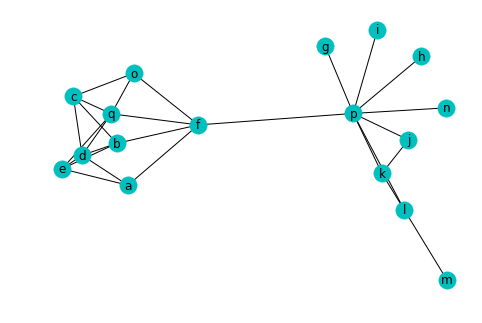

```python
nx.draw(c, node_color='c',edge_color='k', with_labels=True)
nx.density(c)
```

```
0.22727272727272727
```

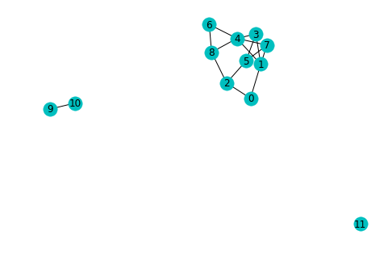

```python
nx.draw(G, node_color='c',edge_color='k', with_labels=True)
nx.density(G)
```

```
0.6
```

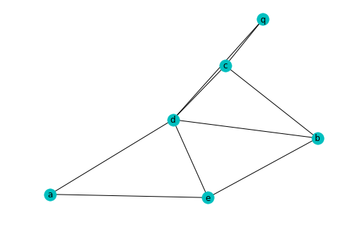

```python
nx.draw(e2, node_color='c',edge_color='k', with_labels=True)
nx.density(e2)
```

### Degree distribution

How many nodes have each possible degree

```python
import pandas as pd
import seaborn as sns
```

```python
degrees = []
for v in c.nodes():
    degrees.append(c.degree(v))
print (degrees)
```

```
[3, 4, 4, 5, 4, 5, 1, 1, 1, 2, 3, 3, 1, 1, 3, 8, 5]
```

```python
#seaborn settings
sns.set_palette("deep", desat=.6)
sns.set_context(rc={"figure.figsize": (8,4)})
```

```
Text(0.5,1,'Degree Histogram')
```

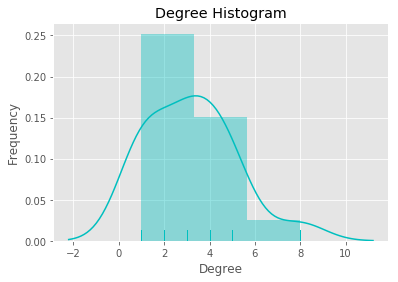

```python
pd_degrees = pd.DataFrame(degrees, columns=['degrees'])
sns.distplot(pd_degrees, rug=True, color="c")
plt.xlabel('Degree')
plt.ylabel('Frequency')
plt.title('Degree Histogram')
```

## Connectivity

Measures how edges are distributed.  
Is a count of the minium number of nodes that would have to be removed before the graph becomes disconnected.

This implementation is based on Kanevsky’s algorithm for finding all minimum-size node cut-sets of an undirected graph $G$; ie the set (or sets) of nodes of cardinality equal to the node connectivity of $G$. Thus if removed, would break $G$ into two or more connected components.

```python
print(nx.node_connectivity(c))
cutsets = list(nx.all_node_cuts(c))
cutsets
```

```
1
```

```
[{'p'}, {'f'}, {'l'}]
```

### Cut nodes and cut edges

```
{('p', 'f')}
{'f'}
```

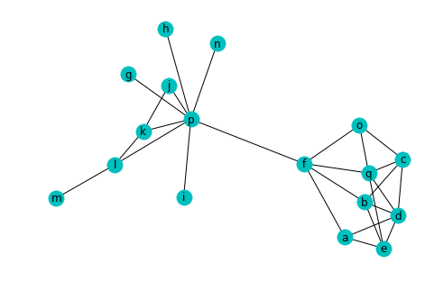

```python
print(nx.minimum_edge_cut(c))
print(nx.minimum_node_cut(c))
nx.draw(c, node_color='c',edge_color='k', with_labels=True)
```

```
2
```

[output not shown]

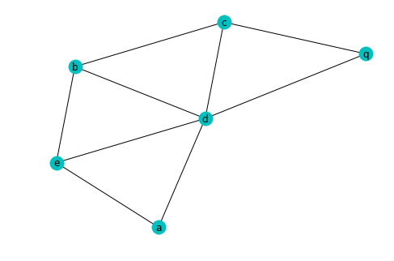

```python
nx.draw(e2, node_color='c',edge_color='k', with_labels=True)
print(nx.node_connectivity(e2))

cutsets = list(nx.all_node_cuts(e2))
cutsets
```

# Social Network Analysis

##### Social Networks Analysis , David Knoke and Song Yang, Sage Publications, 2008.

### The Empiral Study of Social Networks

One of the *"Founding fathers"* **Jacob Moreno**, a Romanian immigrant to America who in 1930s became interested in the **dynamics of social interaction** within groups of people.

In 1934, he published *"Who Shall Survive? A new Approach to the Problem of Human Interrelations."*, which contained the seeds of the field of **sociometry**, which later bacame **social network analysis**.

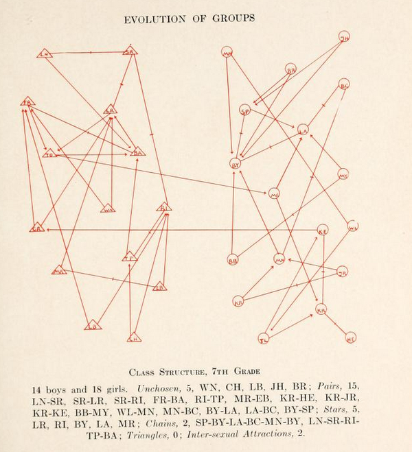

```python
from IPython.display import Image
Image("images/moreno.png")
```

### Networks thinking

Remember that at the same time, different disciplines where trying to represent systems in the form of graphs or networks.

**Alan Turing** in 1936, proposed the theory of computation in his paper *On Computable Numbers, with an Applicationn to the Entscheidungsproblem"*. a.k.a, **Turing Machines**

Taking this network perspective, **Warren McCulloch and Walter Pitts**, years later, published a paper called, *A Logical Calculus of the Ideas Immanent in Nervous Activity*. They wanted to develop a **theory of how the brian worked** modeling cells by neurons.

[figure not shown]

```python
from IPython.display import Image
Image("images/neural.jpg")
```

Von Neumann recognized that the description of cells and their connections could also be applied to electrical components and computation, describing in 1945 this in detail in the paper *First draft of a report on the EDVAC.*

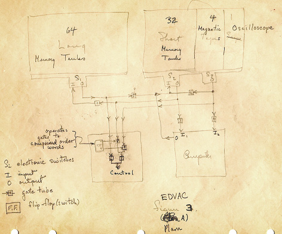

```python
from IPython.display import Image
Image("images/9edvdia.jpg")
```

and from this ... Marvin Minsky took this ideas to further develop theory of computation and artificial intelligence.

## What are Social Networks?

A *social network* is a structure composed of a set of **actors**, some of whose members are **connected by** a set of **one or more relations**.

Is a description of a **social structure** between actors (individuals or organizations). It indicates the ways in which they are **connected** (interact) though various social familiarities.

To probe different type different types of **social interactions** could be represented by different kinds of social networks addressed by different kind of questions.

### Underlying Assumptions

The network perspective emphasizes structural relations as its key oriented principle, where social structure consists of regularities in the patterns of **relations** among concrete **entities**.

- **Entities**: individuals or any kind of organization.
- **Relations**: specific contact, connection or tie between a pair of actors, or *dyad* (*directed or nondirected*).

### Social Network Analysis

Look for the representation and **measurement of these structural relations** accurately, and to explain both why they occur and what are their consequences.

Explicitly assumes that actors **participate in social systems** connecting them to other actors, whose relations comprimse important **influences** on one another's behaviors.

Actors make decisions and act without regard to the other behavior of other actors?

### Network research

- **Detect and represent structures** accurately using relational data.
- To **explain the occurance of different structures** and, at the actor level, to account for varionts in linkages to other actors.

### Pattern relations underlying assumptions

- Structural relations are often more important for **understaging behaviors** than attributes (specific time-place)
- Social networks affect **perceptiosn, beliefs, and actions** through a variety of structural mechanisms that are socially constructed by relations among entities.
- View as a **dynamic process and not static processes**.

By encompasing both structure and entities, it provides conceptual and methodological tools for linking changes in microlevel choices to macrolevel structural alterations.